# Potential Welfare Impacts From the Continued Spread of Wild Pigs

```r
#options(expressions = 5e5)
library(h2o)
library(tidyverse)
library(readxl)
#library(rSymPy)
library(maps)
library(reticulate)
library(choroplethr)
library(choroplethrMaps)
library(triangle)
h2o.no_progress()
source('edm_fx.R')
#data(state.fips)
```

# Abstract

Wild Pigs are spreading across the United States and bringing damage with them. Damage estimates from a survey of producers reported 2014 crop losses of $190 million in 11 US states (Anderson et al. 2016), and associated short-run welfare losses were calculated at $142 million (Holderieath et al. 2018). With approximately 80% of corn, 78% of soybeans, 62% of wheat, 6% of rice, and 1% of peanuts produced in counties that do not have wild pigs, there is a substantial amount of production at risk in the event of continued spread. Preliminary results from an equilibrium displacement model of those crops suggest that if wild pigs inflict a relatively small amount of damage in all counties they are not currently present in, consumer surplus will suffer by $1.154 billion and producer surplus netting a gain of $423 million. McClure et al. (2015) and Snow et al. (2017) have demonstrated that wild pigs can survive in much of the US; however, not all US counties are equally likely to be invaded. This work will integrate the probability of wild pig invasion to find the likely welfare effects of wild pigs continuing to spread.

# Introduction

# Methods

## Probability of Invasion

Snow, Jarzyna, and VerCauteren (2017) used an openBUGS (Bayesian inference Using Gibbs Sampling) model (OpenBUGS 2018) implemented in R (R Core Team 2018) for their prediction of wild pig territory expansion. Spatio-temporal presence data is available (Lutman 2013; Snow, Jarzyna, and VerCauteren 2017), however, the intervals are not even and the data does not specify absence, only presence. Any attempt to use this data as a panel data set for estimation of spread will encounter both spatial and temporal non-stationarity. The non-stationarity should be expected because spatial nearness to wild pigs is one of the best predictors of presence of wild pigs. The time steps are uneven and eradication is rarely observed leading to suspicion over the time dimension. These problems could be corrected to find a consistent estimator (e.g., a within or first differences model). However, maybe another approach is warranted.

The problem at hand is essentially an ecological classification problem. Are wild pigs known to be present? This type of problem has been addressed with a machine learning method known as Random Forest (RF) (Cutler et al. 2007; Walsh et al. 2017). One particularly attractive characteristic of this approach is the lack of reliance on distributional assumptions (Cutler et al. 2007; Walsh et al. 2017). At its most simple, the software builds numerous weighted decision trees and uses those trees to predict an outcome. The intuition of decision trees is also attractive as we can see the importance of variables on the predictions and understand that distance to the nearest known population of wild pigs is an important predictor of wild pig presence, for example (Cook 2017).

Data from the online appendix of Snow, Jarzyna, and VerCauteren (2017) was reshaped to standard panel format with variables in columns and observations across time in rows. Variables for precipitation, stream distance, road miles, and land-use were used in the analysis, however, variables about temperature were dropped due to an apparent loss of prediction accuracy. Temperature is highly correlated with latitude and the RF appeared to put too much weight on those variables, reducing accuracy in predicting presence in later time periods as wild pigs move north. A more spatially direct modeling technique would not need data on distance to nearest known wild pigs because it would be implicit in the model. Adopting the RF approach meant a need to know how far wild pigs are from a given county (that is not itself). Distance between each county within 500 miles (Roth 2014) was combined with wild pig presence data (Lutman 2013) to create a minimum distance to wild pigs from each county variable to pair with the reshaped Snow, Jarzyna, and VerCauteren (2017) data.

A software product, H2O (Cook 2017), was used to implement the RF in R (R Core Team 2018). Training was carried out on the periods 1982-1988, 1988-2004, and 2009-2012. Validation was carried out using a Cross-Validation method with fifty folds. The model was able to predict presence or unknown with approximately nine percent errors. The model was tested with the period 2004-2009 with slightly higher errors of approximately ten percent.

## Spatio-temporal Simulation of Spread

```r
# incorporate predictions to snow data--------------
SIM <- as.data.frame(h2o.predict(m,test_h2o))
SIM <- bind_cols(filter(SNOW, TIME == 4),SIM)
#generate random numbers to compare against prediction
SIM <- SIM %>%
  add_column(random_2020 = runif(nrow(SIM),min = 0, max = 1))%>%
  add_column(random_2028 = runif(nrow(SIM),min = 0, max = 1))%>%
  add_column(random_2036 = runif(nrow(SIM),min = 0, max = 1))
#Time Step 1: 2020
SIM$Id_2020 <- with(SIM, ifelse(is.na(Id_2012),
                                ifelse(random_2020 < present, 1, NA),
                                1))
#update machine learning dependent var
SIM$EXPAND <- with(SIM, ifelse(is.na(Id_2020),
                               "unknown",
                               "present"))
#update distance to nearest
countyPigs <- left_join(by = c('county2' = 'GEOID') , countyPigs, SIM[,c('GEOID','Id_2020')])# join distances to presence
by_cty <- countyPigs %>% group_by(county1)%>%
  filter(Id_2020 == 1) %>%
  filter(mi_to_county == min(mi_to_county))
SIM <- left_join(by = c('GEOID' = 'county1') , SIM, by_cty[,c('county1',"mi_to_county",
                                                              "county2")])
SIM$county2.x <- SIM$mi_to_county.x <- NULL
SIM <- rename(SIM,mi_to_county = mi_to_county.y)
SIM <- rename(SIM,county2 = county2.y)
SIM$mi_to_county <- replace_na(SIM$mi_to_county, 500)
#Time Step 2: 2028
SIMh <- as.h2o(SIM)
REPEAT <- as.data.frame(h2o.predict(m,SIMh))
SIM <- bind_cols(SIM, REPEAT)
SIM$Id_2028 <- with(SIM, ifelse(is.na(Id_2020),
                                ifelse(random_2028 < present1, 1, NA),
                                1))
#update machine learning dependent var
SIM$EXPAND <- with(SIM, ifelse(is.na(Id_2028),
                               "unknown",
                               "present"))
#update distance to nearest
countyPigs <- left_join(by = c('county2' = 'GEOID') , countyPigs, SIM[,c('GEOID','Id_2028')])# join distances to presence
by_cty <- countyPigs %>% group_by(county1)%>%
  filter(Id_2028 == 1) %>%
  filter(mi_to_county == min(mi_to_county))
SIM <- left_join(by = c('GEOID' = 'county1') , SIM, by_cty[,c('county1',"mi_to_county",
                                                              "county2")])
SIM$county2.x <- SIM$mi_to_county.x <- NULL
SIM <- rename(SIM,mi_to_county = mi_to_county.y)
SIM <- rename(SIM,county2 = county2.y)
SIM$mi_to_county <- replace_na(SIM$mi_to_county, 500)
#Time Step 3: 2036
SIMh <- as.h2o(SIM)
REPEAT <- as.data.frame(h2o.predict(m,SIMh))
SIM <- bind_cols(SIM, REPEAT)
SIM$Id_2036 <- with(SIM, ifelse(is.na(Id_2028),
                                ifelse(random_2036 < present2, 1, NA),
                                1))
#update machine learning dependent var
SIM$EXPAND <- with(SIM, ifelse(is.na(Id_2036),
                               "unknown",
                               "present"))
#update distance to nearest
countyPigs <- left_join(by = c('county2' = 'GEOID') , countyPigs, SIM[,c('GEOID','Id_2036')])# join distances to presence
by_cty <- countyPigs %>% group_by(county1)%>%
  filter(Id_2036 == 1) %>%
  filter(mi_to_county == min(mi_to_county))
SIM <- left_join(by = c('GEOID' = 'county1') , SIM, by_cty[,c('county1',"mi_to_county",
                                                              "county2")])
SIM$county2.x <- SIM$mi_to_county.x <- NULL
SIM <- rename(SIM,mi_to_county = mi_to_county.y)
SIM <- rename(SIM,county2 = county2.y)
SIM$mi_to_county <- replace_na(SIM$mi_to_county, 500)
#Time Step 4: 2042
# SIMh <- as.h2o(SIM)
# REPEAT <- as.data.frame(h2o.predict(m,SIMh))
# SIM <- bind_cols(SIM, REPEAT)
# SIM$random <- runif(1,min = 0, max = 1)
# SIM$Id_2042 <- with(SIM, ifelse(is.na(Id_2036),
#                                 ifelse(random < present3, 1, NA),
#                                 1))
# #update machine learning dependent var
# SIM$EXPAND <- with(SIM, ifelse(is.na(Id_2042),
#                                "unknown",
#                                "present"))
# #update distance to nearest
# countyPigs <- left_join(by = c('county2' = 'GEOID') , countyPigs, SIM[,c('GEOID','Id_2042')])# join distances to presence
# by_cty <- countyPigs %>% group_by(county1)%>%
#   filter(Id_2042 == 1) %>%
#   filter(mi_to_county == min(mi_to_county))
# SIM <- left_join(by = c('GEOID' = 'county1') , SIM, by_cty[,c('county1',"mi_to_county",
#                                                               "county2")])
# SIM$county2.x <- SIM$mi_to_county.x <- NULL
# SIM <- rename(SIM,mi_to_county = mi_to_county.y)
# SIM <- rename(SIM,county2 = county2.y)
# SIM$mi_to_county <- replace_na(SIM$mi_to_county, 500)
# Production in 2012 added to simulation data.set-----------------------
Presence <- SIM[,c("GEOID","Id_2020","Id_2028","Id_2036")]
pr_corn_2012 <- read_csv("p_corn_2012.csv", na = "(D)") %>%
  select(`State ANSI`, `County ANSI`, `Value`) %>%
  transmute(FIPS = paste0(`State ANSI`, `County ANSI`),Value) %>%
  rename(p_corn_2012 = Value)
pr_soy_2012 <- read_csv("p_soybeans_2012.csv", na = "(D)") %>%
  select(`State ANSI`, `County ANSI`, `Value`) %>%
  transmute(FIPS = paste0(`State ANSI`, `County ANSI`),Value)%>%
  rename(p_soy_2012 = Value)
```

[output not shown]

```r
pr_wheat_2012 <- read_csv("p_wheat_2012.csv", na = "(D)")%>%
  select(`State ANSI`, `County ANSI`, `Value`) %>%
  transmute(FIPS = paste0(`State ANSI`, `County ANSI`),Value)%>%
  rename(p_wheat_2012 = Value)
```

[output not shown]

```r
pr_rice_2012 <- read_csv("p_rice_2012.csv", na = "(D)")%>%
  select(`State ANSI`, `County ANSI`, `Value`) %>%
  transmute(FIPS = paste0(`State ANSI`, `County ANSI`),Value)%>%
  rename(p_rice_2012 = Value)
pr_peanuts_2012 <- read_csv("p_peanuts_2012.csv", na = "(D)")%>%
  select(`State ANSI`, `County ANSI`, `Value`) %>%
  transmute(FIPS = paste0(`State ANSI`, `County ANSI`),Value)%>%
  rename(p_peanuts_2012 = Value)
SIM <- left_join(by = c('GEOID'='FIPS'),SIM,pr_corn_2012)
SIM <- left_join(by = c('GEOID'='FIPS'),SIM,pr_soy_2012)
SIM <- left_join(by = c('GEOID'='FIPS'),SIM,pr_wheat_2012)
SIM <- left_join(by = c('GEOID'='FIPS'),SIM,pr_rice_2012)
SIM <- left_join(by = c('GEOID'='FIPS'),SIM,pr_peanuts_2012)
#rm(pr_corn_2012,pr_soy_2012,pr_wheat_2012,pr_rice_2012,pr_peanuts_2012)
#replace NA with 0
SIM$Id_2012na <- replace_na(SIM$Id_2012, 0)
SIM$Id_2020 <- replace_na(SIM$Id_2020, 0)
SIM$New_Id_2020 <- SIM$Id_2020 - SIM$Id_2012na
SIM$Id_2028 <- replace_na(SIM$Id_2028, 0)
SIM$New_Id_2028 <- SIM$Id_2028 - SIM$Id_2020
SIM$Id_2036 <- replace_na(SIM$Id_2036, 0)
SIM$New_Id_2036 <- SIM$Id_2036 - SIM$Id_2028
# add exog shock-----
AbstractballparkS4 <- read_csv("AbstractballparkS4.txt")
#2020
SIM$draw_corn_2020 <- rtriangle(nrow(SIM),
                                     a=min(AbstractballparkS4$Corn),
                                     b=max(AbstractballparkS4$Corn),                                   c=(min(AbstractballparkS4$Corn)+max(AbstractballparkS4$Corn))/2)
SIM$EB_corn_2020 <- -1 * SIM$draw_corn_2020 * SIM$New_Id_2020
SIM$draw_soy_2020 <- rtriangle(nrow(SIM),
                                     a=min(AbstractballparkS4$Soybeans),
                                     b=max(AbstractballparkS4$Soybeans),                      c=(min(AbstractballparkS4$Soybeans)+max(AbstractballparkS4$Soybeans))/2)
SIM$EB_soy_2020 <- -1 * SIM$draw_corn_2020 * SIM$New_Id_2020
SIM$draw_wheat_2020 <- rtriangle(nrow(SIM),
                                     a=min(AbstractballparkS4$Wheat),
                                     b=max(AbstractballparkS4$Wheat),                      c=(min(AbstractballparkS4$Wheat)+max(AbstractballparkS4$Wheat))/2)
SIM$EB_wheat_2020 <- -1 * SIM$draw_wheat_2020 * SIM$New_Id_2020
SIM$draw_rice_2020 <- rtriangle(nrow(SIM),
                                     a=min(AbstractballparkS4$Rice),
                                     b=max(AbstractballparkS4$Rice),                      c=(min(AbstractballparkS4$Rice)+max(AbstractballparkS4$Rice))/2)
SIM$EB_rice_2020 <- -1 * SIM$draw_rice_2020 * SIM$New_Id_2020
SIM$draw_peanuts_2020 <- rtriangle(nrow(SIM),
                                     a=min(AbstractballparkS4$Peanuts),
                                     b=max(AbstractballparkS4$Peanuts),                      c=(min(AbstractballparkS4$Peanuts)+max(AbstractballparkS4$Peanuts))/2)
SIM$EB_peanuts_2020 <- -1 * SIM$draw_peanuts_2020 * SIM$New_Id_2020
#2028
SIM$draw_corn_2028 <- rtriangle(nrow(SIM),
                                     a=min(AbstractballparkS4$Corn),
                                     b=max(AbstractballparkS4$Corn),                                   c=(min(AbstractballparkS4$Corn)+max(AbstractballparkS4$Corn))/2)
SIM$EB_corn_2028 <- -1 * SIM$draw_corn_2028 * SIM$New_Id_2028
SIM$draw_soy_2028 <- rtriangle(nrow(SIM),
                                     a=min(AbstractballparkS4$Soybeans),
                                     b=max(AbstractballparkS4$Soybeans),                      c=(min(AbstractballparkS4$Soybeans)+max(AbstractballparkS4$Soybeans))/2)
SIM$EB_soy_2028 <- -1 * SIM$draw_corn_2028 * SIM$New_Id_2028
SIM$draw_wheat_2028 <- rtriangle(nrow(SIM),
                                     a=min(AbstractballparkS4$Wheat),
                                     b=max(AbstractballparkS4$Wheat),                      c=(min(AbstractballparkS4$Wheat)+max(AbstractballparkS4$Wheat))/2)
SIM$EB_wheat_2028 <- -1 * SIM$draw_wheat_2028 * SIM$New_Id_2028
SIM$draw_rice_2028 <- rtriangle(nrow(SIM),
                                     a=min(AbstractballparkS4$Rice),
                                     b=max(AbstractballparkS4$Rice),                      c=(min(AbstractballparkS4$Rice)+max(AbstractballparkS4$Rice))/2)
SIM$EB_rice_2028 <- -1 * SIM$draw_rice_2028 * SIM$New_Id_2028
SIM$draw_peanuts_2028 <- rtriangle(nrow(SIM),
                                     a=min(AbstractballparkS4$Peanuts),
                                     b=max(AbstractballparkS4$Peanuts),                      c=(min(AbstractballparkS4$Peanuts)+max(AbstractballparkS4$Peanuts))/2)
SIM$EB_peanuts_2028 <- -1 * SIM$draw_peanuts_2028 * SIM$New_Id_2028
#2036
SIM$draw_corn_2036 <- rtriangle(nrow(SIM),
                                     a=min(AbstractballparkS4$Corn),
                                     b=max(AbstractballparkS4$Corn),                                   c=(min(AbstractballparkS4$Corn)+max(AbstractballparkS4$Corn))/2)
SIM$EB_corn_2036 <- -1 * SIM$draw_corn_2036 * SIM$New_Id_2036
SIM$draw_soy_2036 <- rtriangle(nrow(SIM),
                                     a=min(AbstractballparkS4$Soybeans),
                                     b=max(AbstractballparkS4$Soybeans),                      c=(min(AbstractballparkS4$Soybeans)+max(AbstractballparkS4$Soybeans))/2)
SIM$EB_soy_2036 <- -1 * SIM$draw_corn_2036 * SIM$New_Id_2036
SIM$draw_wheat_2036 <- rtriangle(nrow(SIM),
                                     a=min(AbstractballparkS4$Wheat),
                                     b=max(AbstractballparkS4$Wheat),                      c=(min(AbstractballparkS4$Wheat)+max(AbstractballparkS4$Wheat))/2)
SIM$EB_wheat_2036 <- -1 * SIM$draw_wheat_2036 * SIM$New_Id_2036
SIM$draw_rice_2036 <- rtriangle(nrow(SIM),
                                     a=min(AbstractballparkS4$Rice),
                                     b=max(AbstractballparkS4$Rice),                      c=(min(AbstractballparkS4$Rice)+max(AbstractballparkS4$Rice))/2)
SIM$EB_rice_2036 <- -1 * SIM$draw_rice_2036 * SIM$New_Id_2036
SIM$draw_peanuts_2036 <- rtriangle(nrow(SIM),
                                     a=min(AbstractballparkS4$Peanuts),
                                     b=max(AbstractballparkS4$Peanuts),                      c=(min(AbstractballparkS4$Peanuts)+max(AbstractballparkS4$Peanuts))/2)
SIM$EB_peanuts_2036 <- -1 * SIM$draw_peanuts_2036 * SIM$New_Id_2036
SIM <- select(SIM, -starts_with('draw_'))
#+++++
rm(by_cty,countyPigs,PigsIn1982,PigsIn1988,PigsIn2004,PigsIn2012,REPEAT,sf12010countydistancemiles_csv,SNOW)
h2o.shutdown(prompt = FALSE)
```

```
[1] TRUE
```

```r
gc()
```

```
          used  (Mb) gc trigger  (Mb) max used  (Mb)
Ncells 2688706 143.6    4539838 242.5  4539838 242.5
Vcells 5568663  42.5   83890184 640.1 87302340 666.1
```

```r
data(continental_us_states)
map_2020 <- SIM %>%
  select(GEOID,Id_2020)%>%
  rename(region = GEOID, value = Id_2020)
map_2020$region <- as.numeric(map_2020$region)
map_2020$value <- as.factor(map_2020$value)
tabulate(map_2020$value)
```

```
[1] 1414 1692
```

```
Your data.frame contains the following regions which are not mappable: 46102The following regions were missing and are being set to NA: 46113, 51515, 25019, 53055
```

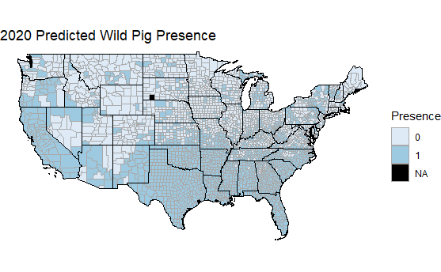

```r
county_choropleth(map_2020,
                  title = "2020 Predicted Wild Pig Presence",
                  legend = "Presence",
                  state_zoom = continental_us_states)
```

```r
map_2028 <- SIM %>%
  select(GEOID,Id_2028)%>%
  rename(region = GEOID, value = Id_2028)
map_2028$region <- as.numeric(map_2028$region)
map_2028$value <- as.factor(map_2028$value)
tabulate(map_2028$value)
```

```
[1] 1030 2076
```

```
Your data.frame contains the following regions which are not mappable: 46102The following regions were missing and are being set to NA: 46113, 51515, 25019, 53055
```

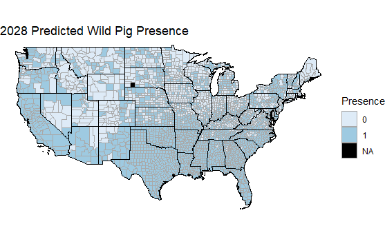

```r
county_choropleth(map_2028,
                  title = "2028 Predicted Wild Pig Presence",
                  legend = "Presence",
                  state_zoom = continental_us_states)
```

```r
map_2036 <- SIM %>%
  select(GEOID,Id_2036)%>%
  rename(region = GEOID, value = Id_2036)
map_2036$region <- as.numeric(map_2036$region)
map_2036$value <- as.factor(map_2036$value)
tabulate(map_2036$value)
```

```
[1]  717 2389
```

```
Your data.frame contains the following regions which are not mappable: 46102The following regions were missing and are being set to NA: 46113, 51515, 25019, 53055
```

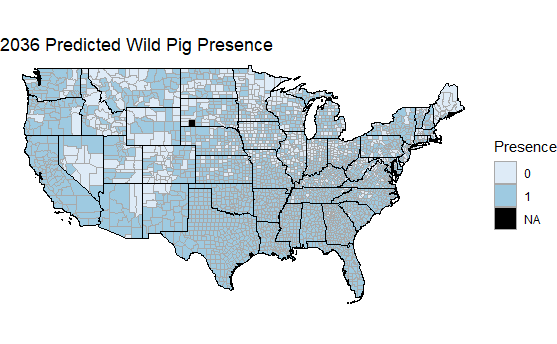

```r
county_choropleth(map_2036,
                  title = "2036 Predicted Wild Pig Presence",
                  legend = "Presence",
                  state_zoom = continental_us_states)
```

## Price Changes

Price changes due to the invasions are found with an equilibrium displacement model (EDM). EDMâs begin with the premise that the market in question is in equilibrium, the market is shocked, and then moves to another equilibrium (Nogueira et al. 2015; Holderieath et al. 2018; Brester, Marsh, and Atwood 2004). For each of the five crops,

$$EP_k* \eta_{kk}^D+\sum_{j=1}^J (EP_k* \eta_{kj}^D)+s_k^{Exports} * EP_k* \eta_{kk}^{Exports}=s_k^{Imports}* EP_k*\eta_kk^{Imports}+ \sum_{fips=1}^{FIPS} (s_k^{fips} *(EP_k* \eta_{kk}^{fips}+ \sum_{j=1}^J(EP_k* \eta_{kj}^{fips})+EB_k^{fips})))$$

are solved simultaneously with the change operator modifying the price of the commodity, $EP_k$, is used to denote the relative change of the price of commodity ($k$), elasticities ($\eta$) of demand ($D$), $exports$, $imports$, and production locations ($fips$) for own price ($kk$) and cross price elasticities ($kj$), production and consumption weights ($s$) with the same notation, and exogenous relative production shocks ($EB$).

Elasticities are the same as used by Holderieath et al. (2018) with additional supply elasticities from FAPRI-MU (2004). Verification of the model was conducted with unit own price elasticities and no cross price elasticities. Price changes with this set of verification elasticities are positive as expected from a restriction of supply.

Exogenous production shocks are randomly drawn from the damage results from Anderson et al. (2016). There is substantial variation between states reported by Anderson et al. (2016) and it is not immediately apparent what states would be most alike with respect to wild pig damage drivers. There are no consumption shocks in the model, so they have been omitted for clarity. The only market level analyzed is at the farm production level, because that is where the damage occurs.

As a matter of programming pragmatism, it would be easier to solve this set of equations if it were of the form $Ax=b$. Five price changes, $x$, could be solved by in this case simplifying to a $5x5$ matrix of weighted elasticities, $A$, and a $5x1$ matrix of weighted exogenous shocks. This can be accomplished with some rearranging.

First, the demand side for corn be expanded as an example. Notice that the domestic consumption does not have a weight. This is due to the derivation of the EDM not including a weight for domestic consumption. In practice a weight of one is assigned domestic consumtption. Second, notice that the export demand equation does not include terms for cross price elasticities. The specification of the EDM did not include cross price elasticities of export demand. In practice elasticities of zero are assigned to these cross price elasticities. Third, notice that there are no exogenous shocks included on the demand side. This was assumed in specification. In practice an exogenous shock of zero was assigned.

$$EP_{corn}* \eta_{corn,corn}^D+\\
EP_{soy}* \eta_{corn,soy}^D+ \\
EP_{wheat}* \eta_{corn,wheat}^D+ \\
EP_{rice}* \eta_{corn,rice}^D+ \\
EP_{peanuts}* \eta_{corn,peanuts}^D+\\
s_{corn}^{Exports} * EP_{corn}* \eta_{kk}^{Exports}$$
Then the supply side. Again, import supply is specified without a shock or cross price elasticites, however, in practice they are assigned zero values. For the sake of compactness, each county’s supply is indexed by the $fips$ identifier. The county weight is distributed.
$$s_k^{Imports}* EP_{corn}*\eta_{corn,corn}^{Imports}+ \\
\sum_{fips=1}^{FIPS} (s_k^{fips} *EP_{corn}* eta_{kk}^{fips}+ \\
s_{corn}^{fips} *EP_{soy}* \eta_{corn,soy}^{fips})+ \\
s_{corn}^{fips} *EP_{wheat}* \eta_{corn,wheat}^{fips})+ \\
s_{corn}^{fips} *EP_{rice}* \eta_{corn,rice}^{fips})+ \\
s_{corn}^{fips} *EP_{peanuts}* \eta_{corn,peanuts}^{fips})+ \\
s_{corn}^{fips} *EB_{corn}^{fips}
)$$
Once assembled as five very long equations without parentesis, the terms on the supply side multiplied by the $EP_k$ terms can be moved to the demand side by multiplying them by $-1$. The exogenous shocks, of zeros, for the demand side can be moved across to take up space. The numerical coefficients being multiplied by the $EP_k$ terms can be collected together by addition. Price changes are found by solving $Ax=b$ for $x$.

```r
# build dfs for price change calculations--------------
crops <- c("corn","soy","wheat",'rice','peanut')
markets <- c("domestic","export")
s <- SIM[,'GEOID']
suppliers <- unique(c("imports",unlist(s)))
variables <- gen_var(crops,markets,suppliers)
EB <- gen_shock(crops, place=suppliers, side = "B")
EC <- gen_shock(crops, place=markets, side = "C")
```

```r
# load elasticities
source('elast.R')
```

```r
# build elasticity of demand df------------
A1 <- as.tibble(e_domestic) %>%
  mutate(rowname = c("domestic_corn", "domestic_soy", "domestic_wheat", "domestic_rice", "domestic_peanut"))
wt_dom <- tibble(rowname = c("domestic_corn", "domestic_soy", "domestic_wheat", "domestic_rice", "domestic_peanut"),
             val = diag(w_domestic))%>%
  rename(weight = val)
dom <- left_join(wt_dom,A1, by = "rowname")
dom <- dom[['weight']] * dom[-(1:2)]#multiply elasticities by weight
dom
```

| corn | soy | wheat | rice | peanut |
| --- | --- | --- | --- | --- |
| -1 | 0 | 0 | 0 | 0 |
| 0 | -1 | 0 | 0 | 0 |
| 0 | 0 | -1 | 0 | 0 |
| 0 | 0 | 0 | -1 | 0 |
| 0 | 0 | 0 | 0 | -1 |

```r
# build elasticity of imports df--------------
A3 <- as.tibble(e_imports) %>%
  mutate(rowname = c("imports_corn", "imports_soy", "imports_wheat", "imports_rice", "imports_peanut"))
wt_imp <- tibble(rowname = c("imports_corn", "imports_soy", "imports_wheat", "imports_rice", "imports_peanut"),
              val = diag(ss_imports))%>%
  rename(weight = val)
imp <- left_join(wt_imp,A3, by = "rowname")
imp$weight <- -1 * imp$weight #move import supply to left side of equal sign
imp <- imp[['weight']] * imp[-(1:2)]#multiply elasticities by weight
imp
```

| corn | soy | wheat | rice | peanut |
| --- | --- | --- | --- | --- |
| -0.01 | 0.00 | 0.00 | 0.00 | 0.00 |
| 0.00 | -0.02 | 0.00 | 0.00 | 0.00 |
| 0.00 | 0.00 | -0.12 | 0.00 | 0.00 |
| 0.00 | 0.00 | 0.00 | -0.17 | 0.00 |
| 0.00 | 0.00 | 0.00 | 0.00 | -0.03 |

```r
# build elasticity of exports df --------
A2 <- as.tibble(e_export) %>%
  mutate(rowname = c("export_corn", "export_soy", "export_wheat", "export_rice", "export_peanut"))
wt_exp <- tibble(rowname = c("export_corn", "export_soy", "export_wheat", "export_rice", "export_peanut"),
                 val = diag(w_export))%>%
  rename(weight = val)
exp <-  left_join(wt_exp,A2, by = "rowname")
exp <- exp[['weight']] * exp[-(1:2)]#multiply elasticities by weight
exp
```

| corn | soy | wheat | rice | peanut |
| --- | --- | --- | --- | --- |
| 0.14 | 0.00 | 0.0 | 0.00 | 0.00 |
| 0.00 | 0.83 | 0.0 | 0.00 | 0.00 |
| 0.00 | 0.00 | 0.8 | 0.00 | 0.00 |
| 0.00 | 0.00 | 0.0 | 0.84 | 0.00 |
| 0.00 | 0.00 | 0.0 | 0.00 | 0.23 |

```r
# build elasticity of domestic suppliers df ------------
ve <- variables %>%
  unlist()%>%
  str_subset("\\b[e]_[:digit:]{5}.")%>%
  as.tibble()%>%
  rename(name = value)
ve$reg<- ve$name %>%
  str_replace_all("\\b[e]_(20|31)[:digit:]{3}.","e_Central_Plains_")%>%
  str_replace_all("\\b[e]_(17|18|19|29|39)[:digit:]{3}.","e_Corn_Belt_")%>%
  str_replace_all("\\b[e]_(05|22|28)[:digit:]{3}.","e_Delta_States_")%>%
  str_replace_all("\\b[e]_(04|06|08|16|30|32|35|41|49|53|56)[:digit:]{3}.","e_Far_West_")%>%
  str_replace_all("\\b[e]_(26|27|55)[:digit:]{3}.","e_Lake_States_")%>%
  str_replace_all("\\b[e]_(09|10|11|23|24|25|33|34|36|42|44|50|54)[:digit:]{3}.","e_Northeast_")%>%
  str_replace_all("\\b[e]_(38|46)[:digit:]{3}.","e_Northern_Plains_")%>%
  str_replace_all("\\b[e]_(01|12|13|21|37|45|47|51)[:digit:]{3}.","e_Southeast_")%>%
  str_replace_all("\\b[e]_(40|48)[:digit:]{3}.","e_Southern_Plains_")
temp <-   paste0(
  str_extract(ve$reg,'\\b[e]_'),
  str_extract(ve$reg,'(Central_Plains|Corn_Belt|Delta_States|Far_West|Lake_States|Northeast|Northern_Plains|Southeast|Southern_Plains)'),"['",
  str_extract(ve$reg,'(corn|soy|wheat|rice|peanut){1}'),"','",
  str_extract(ve$reg,'(corn|soy|wheat|rice|peanut)\\b'),"']"
)
ve$val <-  purrr::map_dbl(temp, eval_parse)
EBL <- tibble(EB) %>%
    rename(name = EB)%>%
    filter(str_detect(name, "\\bEB_[:digit:]{5}."))%>%
    mutate(rowname = substr(name,4,18))
# rownames------------
rn <- EBL$rowname
A4_corn <- as.tibble(ve %>%
                       filter(str_detect(name, "corn_corn$"))%>%
                       select(val) %>%
                       as_vector()) %>%
  add_column(soy = ve %>%
               filter(str_detect(name, "soy_corn$"))%>%
               select(val) %>%
               as_vector())%>%
  add_column(wheat = ve %>%
               filter(str_detect(name, "wheat_corn$"))%>%
               select(val) %>%
               as_vector())%>%
  add_column(rice = ve %>%
               filter(str_detect(name, "rice_corn$"))%>%
               select(val) %>%
               as_vector())%>%
  add_column(peanut = ve %>%
               filter(str_detect(name, "peanut_corn$"))%>%
               select(val) %>%
               as_vector()) %>%
  rename(corn = value)%>%
  mutate(rowname = str_subset(rn,"\\b[:digit:]{5}.corn$"))

A4_soy <- as.tibble(ve %>%
                       filter(str_detect(name, "corn_soy$"))%>%
                       select(val) %>%
                       as_vector()) %>%
  add_column(soy = ve %>%
               filter(str_detect(name, "soy_soy$"))%>%
               select(val) %>%
               as_vector())%>%
  add_column(wheat = ve %>%
               filter(str_detect(name, "wheat_soy$"))%>%
               select(val) %>%
               as_vector())%>%
  add_column(rice = ve %>%
               filter(str_detect(name, "rice_soy$"))%>%
               select(val) %>%
               as_vector())%>%
  add_column(peanut = ve %>%
               filter(str_detect(name, "peanut_soy$"))%>%
               select(val) %>%
               as_vector()) %>%
  rename(corn = value)%>%
  mutate(rowname = str_subset(rn,"\\b[:digit:]{5}.soy$"))
A4_wheat <- as.tibble(ve %>%
                      filter(str_detect(name, "corn_wheat$"))%>%
                      select(val) %>%
                      as_vector()) %>%
  add_column(soy = ve %>%
               filter(str_detect(name, "soy_wheat$"))%>%
               select(val) %>%
               as_vector())%>%
  add_column(wheat = ve %>%
               filter(str_detect(name, "wheat_wheat$"))%>%
               select(val) %>%
               as_vector())%>%
  add_column(rice = ve %>%
               filter(str_detect(name, "rice_wheat$"))%>%
               select(val) %>%
               as_vector())%>%
  add_column(peanut = ve %>%
               filter(str_detect(name, "peanut_wheat$"))%>%
               select(val) %>%
               as_vector()) %>%
  rename(corn = value)%>%
  mutate(rowname = str_subset(rn,"\\b[:digit:]{5}.wheat$"))
A4_rice <- as.tibble(ve %>%
                      filter(str_detect(name, "corn_rice$"))%>%
                      select(val) %>%
                      as_vector()) %>%
  add_column(soy = ve %>%
               filter(str_detect(name, "soy_rice$"))%>%
               select(val) %>%
               as_vector())%>%
  add_column(wheat = ve %>%
               filter(str_detect(name, "wheat_rice$"))%>%
               select(val) %>%
               as_vector())%>%
  add_column(rice = ve %>%
               filter(str_detect(name, "rice_rice$"))%>%
               select(val) %>%
               as_vector())%>%
  add_column(peanut = ve %>%
               filter(str_detect(name, "peanut_rice$"))%>%
               select(val) %>%
               as_vector()) %>%
  rename(corn = value)%>%
  mutate(rowname = str_subset(rn,"\\b[:digit:]{5}.rice$"))
A4_peanut <- as.tibble(ve %>%
                      filter(str_detect(name, "corn_peanut$"))%>%
                      select(val) %>%
                      as_vector()) %>%
  add_column(soy = ve %>%
               filter(str_detect(name, "soy_peanut$"))%>%
               select(val) %>%
               as_vector())%>%
  add_column(wheat = ve %>%
               filter(str_detect(name, "wheat_peanut$"))%>%
               select(val) %>%
               as_vector())%>%
  add_column(rice = ve %>%
               filter(str_detect(name, "rice_peanut$"))%>%
               select(val) %>%
               as_vector())%>%
  add_column(peanut = ve %>%
               filter(str_detect(name, "peanut_peanut$"))%>%
               select(val) %>%
               as_vector()) %>%
  rename(corn = value)%>%
  mutate(rowname = str_subset(rn,"\\b[:digit:]{5}.peanut$"))
# unweighted supply A df------------
A_dom_supply <-  bind_rows(list(A4_corn,A4_soy,A4_wheat,A4_rice,A4_peanut))
A_dom_supply
```

| corn | soy | wheat | rice | peanut | rowname |
| --- | --- | --- | --- | --- | --- |
| 1 | 0 | 0 | 0 | 0 | 31039_corn |
| 1 | 0 | 0 | 0 | 0 | 53069_corn |
| 1 | 0 | 0 | 0 | 0 | 35011_corn |
| 1 | 0 | 0 | 0 | 0 | 31109_corn |
| 1 | 0 | 0 | 0 | 0 | 31129_corn |
| 1 | 0 | 0 | 0 | 0 | 46099_corn |
| 1 | 0 | 0 | 0 | 0 | 48327_corn |
| 1 | 0 | 0 | 0 | 0 | 06091_corn |
| 1 | 0 | 0 | 0 | 0 | 21053_corn |
| 1 | 0 | 0 | 0 | 0 | 39063_corn |

[output cut: 990 more lines]

```r
#supply weights------------
Total_Corn_Supply <- 16942000000
Total_Soy_Supply <-  4719000000
Total_Wheat_Supply <- 3079000000
Total_Rice_Supply <- 249170000
Total_Peanut_Supply <- 8800000000
SIM$ss__corn <- SIM$p_corn_2012/Total_Corn_Supply
SIM$ss__soy <- SIM$p_soy_2012/Total_Soy_Supply
SIM$ss__wheat <- SIM$p_wheat_2012/Total_Wheat_Supply
SIM$ss__rice <- SIM$p_rice_2012/Total_Rice_Supply
SIM$ss__peanut <- SIM$p_peanuts_2012/Total_Peanut_Supply
SIM$ss__corn <- replace_na(SIM$ss__corn,0)
SIM$ss__soy <- replace_na(SIM$ss__soy,0)
SIM$ss__wheat <- replace_na(SIM$ss__wheat,0)
SIM$ss__rice <- replace_na(SIM$ss__rice,0)
SIM$ss__peanut <- replace_na(SIM$ss__peanut,0)
tmp_Pres <- SIM %>%
  select(GEOID,ss__corn,ss__soy,ss__wheat,ss__rice,ss__peanut)
vw <-  variables %>%
  unlist() %>%
  str_subset("\\b[ss_]") %>%
  as.tibble() %>%
  rename(name = value)%>%
  filter(str_detect(name, "imports") == FALSE)
names <- vw$name
result <- list()
x <- paste0("ss__",str_extract(names,'(corn|soy|wheat|rice|peanut){1}'))
y <- str_extract(names,"[:digit:]{5}")
result <- map2_dbl(x,y,ssLookup,data=tmp_Pres)
vw <- vw %>%
  add_column(val = result)%>%
    rename(rowname = name)%>%
  mutate(rowname = substr(rowname,4,19))
rm(Total_Corn_Supply,Total_Soy_Supply,Total_Wheat_Supply,
   Total_Rice_Supply,Total_Peanut_Supply,tmp_Pres,names,x,y,result)
#domestic supply -----------------------------------
sup_corn <- left_join(A4_corn,vw, by = "rowname")%>%
  rename(weight = val)
sup_corn$weight <- -1 * sup_corn$weight #move domestic supply to left side of equal sign
sup_corn <- sup_corn[['weight']] * sup_corn[(1:5)]#multiply elasticities by weight
sup_corn <- summarise_all(sup_corn,sum)
sup_soy <- left_join(A4_soy,vw, by = "rowname")%>%
  rename(weight = val)
sup_soy$weight <- -1 * sup_soy$weight #move domestic supply to left side of equal sign
sup_soy <- sup_soy[['weight']] * sup_soy[(1:5)]#multiply elasticities by weight
sup_soy <- summarise_all(sup_soy,sum)
sup_wheat <- left_join(A4_wheat,vw, by = "rowname")%>%
  rename(weight = val)
sup_wheat$weight <- -1 * sup_wheat$weight #move domestic supply to left side of equal sign
sup_wheat <- sup_wheat[['weight']] * sup_wheat[(1:5)]#multiply elasticities by weight
sup_wheat <- summarise_all(sup_wheat,sum)
sup_rice <- left_join(A4_rice,vw, by = "rowname")%>%
  rename(weight = val)
sup_rice$weight <- -1 * sup_rice$weight #move domestic supply to left side of equal sign
sup_rice <- sup_rice[['weight']] * sup_rice[(1:5)]#multiply elasticities by weight
sup_rice <- summarise_all(sup_rice,sum)
sup_peanut <- left_join(A4_peanut,vw, by = "rowname")%>%
  rename(weight = val)
sup_peanut$weight <- -1 * sup_peanut$weight #move domestic supply to left side of equal sign
sup_peanut <- sup_peanut[['weight']] * sup_peanut[(1:5)]#multiply elasticities by weight
sup_peanut <- summarise_all(sup_peanut,sum)
```

```r
#combine into A mat------------------
A_s_corn <- dom[1,] + exp[1,] + imp[1,] + sup_corn
A_s_soy <- dom[2,] + exp[2,] + imp[2,] + sup_soy
A_s_wheat  <- dom[3,] + exp[3,] + imp[3,] + sup_wheat
A_s_rice <- dom[4,] + exp[4,] + imp[4,] + sup_rice
A_s_peanut <- dom[5,] + exp[5,] + imp[5,] + sup_peanut
A <- bind_rows(A_s_corn,
            A_s_soy,
            A_s_wheat,
            A_s_rice,
            A_s_peanut
            )%>%
  as.matrix()
A
```

```
          corn        soy     wheat      rice    peanut
[1,] -1.479017  0.0000000  0.000000  0.000000  0.000000
[2,]  0.000000 -0.6519437  0.000000  0.000000  0.000000
[3,]  0.000000  0.0000000 -1.027994  0.000000  0.000000
[4,]  0.000000  0.0000000  0.000000 -1.125742  0.000000
[5,]  0.000000  0.0000000  0.000000  0.000000 -1.534263
```

```r
# build exogenous shock matrix b
# all shocks are domestic supply shocks
# because we are going with a 5x5 * 5x1 we do not need to
# evaluate other shocks as zeros to hold
# places
# production shocks -----------
#The shocks are on the production side of the equilibrium conditions.
vws <- vw%>%
  rename(weight = val)
# 2020==================================================
EBL_2020 <- tibble(EB) %>%
  rename(name = EB)%>%
  add_column(val = c(0,SIM[,'EB_corn_2020', drop = TRUE],
                     0,SIM[,'EB_soy_2020', drop = TRUE],
                     0,SIM[,'EB_wheat_2020', drop = TRUE],
                     0,SIM[,'EB_rice_2020', drop = TRUE],
                     0,SIM[,'EB_peanuts_2020', drop = TRUE]))
b_sup_corn <- EBL_2020 %>%
  filter(str_detect(name, "\\bEB_[:digit:]{5}."))%>%
  filter(str_detect(name, 'corn\\b'))%>%
  mutate(rowname = substr(name,4,18))
b_sup_corn <- left_join(b_sup_corn,vws, by = 'rowname')
b_sup_corn$wtedshock <- b_sup_corn$val * b_sup_corn$weight
b_sup_soy <- EBL_2020 %>%
  filter(str_detect(name, "\\bEB_[:digit:]{5}."))%>%
  filter(str_detect(name, 'soy\\b'))%>%
  mutate(rowname = substr(name,4,18))
b_sup_soy <- left_join(b_sup_soy,vws, by = 'rowname')
b_sup_soy$wtedshock <- b_sup_soy$val * b_sup_soy$weight
b_sup_wheat <- EBL_2020 %>%
  filter(str_detect(name, "\\bEB_[:digit:]{5}."))%>%
  filter(str_detect(name, 'wheat\\b'))%>%
  mutate(rowname = substr(name,4,18))
b_sup_wheat <- left_join(b_sup_wheat,vws, by = 'rowname')
b_sup_wheat$wtedshock <- b_sup_wheat$val * b_sup_wheat$weight
b_sup_rice <- EBL_2020 %>%
  filter(str_detect(name, "\\bEB_[:digit:]{5}."))%>%
  filter(str_detect(name, 'rice\\b'))%>%
  mutate(rowname = substr(name,4,18))
b_sup_rice <- left_join(b_sup_rice,vws, by = 'rowname')
b_sup_rice$wtedshock <- b_sup_rice$val * b_sup_rice$weight
b_sup_peanut <- EBL_2020 %>%
  filter(str_detect(name, "\\bEB_[:digit:]{5}."))%>%
  filter(str_detect(name, 'peanut\\b'))%>%
  mutate(rowname = substr(name,4,18))
b_sup_peanut <- left_join(b_sup_peanut,vws, by = 'rowname')
b_sup_peanut$wtedshock <- b_sup_peanut$val * b_sup_peanut$weight
#combine into b mat------------------
shock_2020 <-
  matrix(c(corn = sum(b_sup_corn[,5]),
            soy = sum(b_sup_soy[,5]),
            wheat = sum(b_sup_wheat[,5]),
            rice = sum(b_sup_rice[,5]),
            peanuts = sum(b_sup_peanut[,5])),nrow=5)
#2028========================================================
EBL_2028 <- tibble(EB) %>%
  rename(name = EB)%>%
  add_column(val = c(0,SIM[,'EB_corn_2028', drop = TRUE],
                     0,SIM[,'EB_soy_2028', drop = TRUE],
                     0,SIM[,'EB_wheat_2028', drop = TRUE],
                     0,SIM[,'EB_rice_2028', drop = TRUE],
                     0,SIM[,'EB_peanuts_2028', drop = TRUE]))
b_sup_corn <- EBL_2028 %>%
  filter(str_detect(name, "\\bEB_[:digit:]{5}."))%>%
  filter(str_detect(name, 'corn\\b'))%>%
  mutate(rowname = substr(name,4,18))
b_sup_corn <- left_join(b_sup_corn,vws, by = 'rowname')
b_sup_corn$wtedshock <- b_sup_corn$val * b_sup_corn$weight
b_sup_soy <- EBL_2028 %>%
  filter(str_detect(name, "\\bEB_[:digit:]{5}."))%>%
  filter(str_detect(name, 'soy\\b'))%>%
  mutate(rowname = substr(name,4,18))
b_sup_soy <- left_join(b_sup_soy,vws, by = 'rowname')
b_sup_soy$wtedshock <- b_sup_soy$val * b_sup_soy$weight
b_sup_wheat <- EBL_2028 %>%
  filter(str_detect(name, "\\bEB_[:digit:]{5}."))%>%
  filter(str_detect(name, 'wheat\\b'))%>%
  mutate(rowname = substr(name,4,18))
b_sup_wheat <- left_join(b_sup_wheat,vws, by = 'rowname')
b_sup_wheat$wtedshock <- b_sup_wheat$val * b_sup_wheat$weight
b_sup_rice <- EBL_2028 %>%
  filter(str_detect(name, "\\bEB_[:digit:]{5}."))%>%
  filter(str_detect(name, 'rice\\b'))%>%
  mutate(rowname = substr(name,4,18))
b_sup_rice <- left_join(b_sup_rice,vws, by = 'rowname')
b_sup_rice$wtedshock <- b_sup_rice$val * b_sup_rice$weight
b_sup_peanut <- EBL_2028 %>%
  filter(str_detect(name, "\\bEB_[:digit:]{5}."))%>%
  filter(str_detect(name, 'peanut\\b'))%>%
  mutate(rowname = substr(name,4,18))
b_sup_peanut <- left_join(b_sup_peanut,vws, by = 'rowname')
b_sup_peanut$wtedshock <- b_sup_peanut$val * b_sup_peanut$weight
#combine into b mat------------------
shock_2028 <-
  matrix(c(corn = sum(b_sup_corn[,5]),
            soy = sum(b_sup_soy[,5]),
            wheat = sum(b_sup_wheat[,5]),
            rice = sum(b_sup_rice[,5]),
            peanuts = sum(b_sup_peanut[,5])),nrow=5)
#2036=======================================================
EBL_2036 <- tibble(EB) %>%
  rename(name = EB)%>%
  add_column(val = c(0,SIM[,'EB_corn_2036', drop = TRUE],
                     0,SIM[,'EB_soy_2036', drop = TRUE],
                     0,SIM[,'EB_wheat_2036', drop = TRUE],
                     0,SIM[,'EB_rice_2036', drop = TRUE],
                     0,SIM[,'EB_peanuts_2036', drop = TRUE]))
b_sup_corn <- EBL_2036 %>%
  filter(str_detect(name, "\\bEB_[:digit:]{5}."))%>%
  filter(str_detect(name, 'corn\\b'))%>%
  mutate(rowname = substr(name,4,18))
b_sup_corn <- left_join(b_sup_corn,vws, by = 'rowname')
b_sup_corn$wtedshock <- b_sup_corn$val * b_sup_corn$weight
b_sup_soy <- EBL_2036 %>%
  filter(str_detect(name, "\\bEB_[:digit:]{5}."))%>%
  filter(str_detect(name, 'soy\\b'))%>%
  mutate(rowname = substr(name,4,18))
b_sup_soy <- left_join(b_sup_soy,vws, by = 'rowname')
b_sup_soy$wtedshock <- b_sup_soy$val * b_sup_soy$weight
b_sup_wheat <- EBL_2036 %>%
  filter(str_detect(name, "\\bEB_[:digit:]{5}."))%>%
  filter(str_detect(name, 'wheat\\b'))%>%
  mutate(rowname = substr(name,4,18))
b_sup_wheat <- left_join(b_sup_wheat,vws, by = 'rowname')
b_sup_wheat$wtedshock <- b_sup_wheat$val * b_sup_wheat$weight
b_sup_rice <- EBL_2036 %>%
  filter(str_detect(name, "\\bEB_[:digit:]{5}."))%>%
  filter(str_detect(name, 'rice\\b'))%>%
  mutate(rowname = substr(name,4,18))
b_sup_rice <- left_join(b_sup_rice,vws, by = 'rowname')
b_sup_rice$wtedshock <- b_sup_rice$val * b_sup_rice$weight
b_sup_peanut <- EBL_2036 %>%
  filter(str_detect(name, "\\bEB_[:digit:]{5}."))%>%
  filter(str_detect(name, 'peanut\\b'))%>%
  mutate(rowname = substr(name,4,18))
b_sup_peanut <- left_join(b_sup_peanut,vws, by = 'rowname')
b_sup_peanut$wtedshock <- b_sup_peanut$val * b_sup_peanut$weight
#combine into b mat------------------
shock_2036 <-
  matrix(c(corn = sum(b_sup_corn[,5]),
            soy = sum(b_sup_soy[,5]),
            wheat = sum(b_sup_wheat[,5]),
            rice = sum(b_sup_rice[,5]),
            peanuts = sum(b_sup_peanut[,5])),nrow=5)
```

```r
#solve for price changes ------------------------------
chgs_2020 <- solve(A,shock_2020)
chgs_2028 <- solve(A,shock_2028)
chgs_2036 <- solve(A,shock_2036)
```

```r
#new prices
#2012 Prices from NASS
Prices <- tribble(
    ~P_2012,
    6.89,
    14.4,
    7.77,
    15.1,
    0.301
        )
Prices <- Prices %>%
    add_column(chgs_2020 = as.vector(chgs_2020))%>%
    add_column(chgs_2028 = as.vector(chgs_2028))%>%
    add_column(chgs_2036 = as.vector(chgs_2036))
Prices <- Prices %>%
    mutate(chgs_2020 = chgs_2020 + 1)%>%
    mutate(chgs_2028 = chgs_2028 + 1)%>%
    mutate(chgs_2036 = chgs_2036 + 1)
Prices <- Prices %>%
    mutate(P_2020 = P_2012 * chgs_2020)%>%
    mutate(P_2028 = P_2020 * chgs_2028)%>%
    mutate(P_2036 = P_2028 * chgs_2036)%>%
  add_column(rownames = c("corn", "soy", "wheat", "rice", "peanuts"))%>%
  column_to_rownames(var="rownames")
```

```
Setting row names on a tibble is deprecated.
```

```r
#quantities
vet <- ve %>%
    mutate(GEOID = str_extract(name,"[:digit:]{5}"))%>%
    mutate(Var = paste0('e_',
                        str_extract(name, '(corn|soy|wheat|rice|peanut){1}'),"_",
                        str_extract(name, '(corn|soy|wheat|rice|peanut)\\b')))%>%
    select(-reg)%>%
    reshape2::dcast(GEOID ~ Var, value.var = 'val')
SIM <- left_join(SIM,vet, by = 'GEOID')
SIM$price_corn_2012 <- Prices[['corn','P_2012']]
SIM$price_soy_2012 <- Prices[['soy','P_2012']]
SIM$price_wheat_2012 <- Prices[['wheat','P_2012']]
SIM$price_rice_2012 <- Prices[['rice','P_2012']]
SIM$price_peanuts_2012 <- Prices[['peanuts','P_2012']]
SIM$price_corn_2020 <- Prices[['corn','P_2020']]
SIM$price_soy_2020 <- Prices[['soy','P_2020']]
SIM$price_wheat_2020 <- Prices[['wheat','P_2020']]
SIM$price_rice_2020 <- Prices[['rice','P_2020']]
SIM$price_peanuts_2020 <- Prices[['peanuts','P_2020']]
SIM$price_corn_2028 <- Prices[['corn','P_2028']]
SIM$price_soy_2028 <- Prices[['soy','P_2028']]
SIM$price_wheat_2028 <- Prices[['wheat','P_2028']]
SIM$price_rice_2028 <- Prices[['rice','P_2028']]
SIM$price_peanuts_2028 <- Prices[['peanuts','P_2028']]
SIM$price_corn_2036 <- Prices[['corn','P_2036']]
SIM$price_soy_2036 <- Prices[['soy','P_2036']]
SIM$price_wheat_2036 <- Prices[['wheat','P_2036']]
SIM$price_rice_2036 <- Prices[['rice','P_2036']]
SIM$price_peanuts_2036 <- Prices[['peanuts','P_2036']]
#---------------
SIM$EP_corn_2020 <- 1- Prices[['corn','chgs_2020']]
SIM$EP_soy_2020 <- 1- Prices[['soy','chgs_2020']]
SIM$EP_wheat_2020 <- 1- Prices[['wheat','chgs_2020']]
SIM$EP_rice_2020 <- 1- Prices[['rice','chgs_2020']]
SIM$EP_peanuts_2020 <- 1- Prices[['peanuts','chgs_2020']]
SIM$EP_corn_2028 <- 1- Prices[['corn','chgs_2028']]
SIM$EP_soy_2028 <- 1- Prices[['soy','chgs_2028']]
SIM$EP_wheat_2028 <- 1- Prices[['wheat','chgs_2028']]
SIM$EP_rice_2028 <- 1- Prices[['rice','chgs_2028']]
SIM$EP_peanuts_2028 <- 1- Prices[['peanuts','chgs_2028']]
SIM$EP_corn_2036 <- 1- Prices[['corn','chgs_2036']]
SIM$EP_soy_2036 <- 1- Prices[['soy','chgs_2036']]
SIM$EP_wheat_2036 <- 1- Prices[['wheat','chgs_2036']]
SIM$EP_rice_2036 <- 1- Prices[['rice','chgs_2036']]
SIM$EP_peanuts_2036 <- 1- Prices[['peanuts','chgs_2036']]
#------------------------------------------------------------
SIM$q_corn_2020 <- (SIM$p_corn_2012 * (1 + (SIM$ss__corn * (SIM$e_corn_corn * SIM$EP_corn_2020 + SIM$e_corn_soy * SIM$EP_soy_2020 + SIM$e_corn_wheat * SIM$EP_wheat_2020 + SIM$e_corn_rice * SIM$EP_rice_2020 + SIM$e_corn_peanut * SIM$EP_peanuts_2020))))%>%replace_na(0)
SIM$q_soy_2020 <- (SIM$p_soy_2012 * (1 + (SIM$ss__soy * (SIM$e_soy_corn * SIM$EP_corn_2020 + SIM$e_soy_soy * SIM$EP_soy_2020 + SIM$e_soy_wheat * SIM$EP_wheat_2020 + SIM$e_soy_rice * SIM$EP_rice_2020 + SIM$e_soy_peanut * SIM$EP_peanuts_2020))))%>%replace_na(0)
SIM$q_wheat_2020 <- (SIM$p_wheat_2012 * (1 + (SIM$ss__wheat * (SIM$e_wheat_corn * SIM$EP_corn_2020 + SIM$e_wheat_soy * SIM$EP_soy_2020 + SIM$e_wheat_wheat * SIM$EP_wheat_2020 + SIM$e_wheat_rice * SIM$EP_rice_2020 + SIM$e_wheat_peanut * SIM$EP_peanuts_2020))))%>%replace_na(0)
SIM$q_rice_2020 <- (SIM$p_rice_2012 * (1 + (SIM$ss__rice * (SIM$e_rice_corn * SIM$EP_corn_2020 + SIM$e_rice_soy * SIM$EP_soy_2020 + SIM$e_rice_wheat * SIM$EP_wheat_2020 + SIM$e_rice_rice * SIM$EP_rice_2020 + SIM$e_rice_peanut * SIM$EP_peanuts_2020))))%>%replace_na(0)
SIM$q_peanuts_2020 <- (SIM$p_peanuts_2012 * (1 + (SIM$ss__peanut * (SIM$e_peanut_corn * SIM$EP_corn_2020 + SIM$e_peanut_soy * SIM$EP_soy_2020 + SIM$e_peanut_wheat * SIM$EP_wheat_2020 + SIM$e_peanut_rice * SIM$EP_rice_2020 + SIM$e_peanut_peanut * SIM$EP_peanuts_2020))))%>%replace_na(0)
#---------------------------
SIM$q_corn_2028 <- (SIM$q_corn_2020 * (1 + (SIM$ss__corn * (SIM$e_corn_corn * SIM$EP_corn_2028 + SIM$e_corn_soy * SIM$EP_soy_2028 + SIM$e_corn_wheat * SIM$EP_wheat_2028 + SIM$e_corn_rice * SIM$EP_rice_2028 + SIM$e_corn_peanut * SIM$EP_peanuts_2028))))%>%replace_na(0)
SIM$q_soy_2028 <- (SIM$q_soy_2020 * (1 + (SIM$ss__soy * (SIM$e_corn_corn * SIM$EP_corn_2028 + SIM$e_corn_soy * SIM$EP_soy_2028 + SIM$e_soy_wheat * SIM$EP_wheat_2028 + SIM$e_soy_rice * SIM$EP_rice_2028 + SIM$e_soy_peanut * SIM$EP_peanuts_2028))))%>%replace_na(0)
SIM$q_wheat_2028 <- (SIM$q_wheat_2020 * (1 + (SIM$ss__wheat * (SIM$e_wheat_corn * SIM$EP_corn_2028 + SIM$e_wheat_soy * SIM$EP_soy_2028 + SIM$e_wheat_wheat * SIM$EP_wheat_2028 + SIM$e_wheat_rice * SIM$EP_rice_2028 + SIM$e_wheat_peanut * SIM$EP_peanuts_2028))))%>%replace_na(0)
SIM$q_rice_2028 <- (SIM$q_rice_2020 * (1 + (SIM$ss__rice * (SIM$e_rice_corn * SIM$EP_corn_2028 + SIM$e_rice_soy * SIM$EP_soy_2028 + SIM$e_rice_wheat * SIM$EP_wheat_2028 + SIM$e_rice_rice * SIM$EP_rice_2028 + SIM$e_rice_peanut * SIM$EP_peanuts_2028))))%>%replace_na(0)
SIM$q_peanuts_2028 <- (SIM$q_peanuts_2020 * (1 + (SIM$ss__peanut * (SIM$e_peanut_corn * SIM$EP_corn_2028 + SIM$e_peanut_soy * SIM$EP_soy_2028 + SIM$e_peanut_wheat * SIM$EP_wheat_2028 + SIM$e_peanut_rice * SIM$EP_rice_2028 + SIM$e_peanut_peanut * SIM$EP_peanuts_2028))))%>%replace_na(0)
#----------------------------------
SIM$q_corn_2036 <- (SIM$q_corn_2028 * (1 + (SIM$ss__corn * (SIM$e_corn_corn * SIM$EP_corn_2036 + SIM$e_corn_soy * SIM$EP_soy_2036 + SIM$e_corn_wheat * SIM$EP_wheat_2036 + SIM$e_corn_rice * SIM$EP_rice_2036 + SIM$e_corn_peanut * SIM$EP_peanuts_2036))))%>%replace_na(0)
SIM$q_soy_2036 <- (SIM$q_soy_2028 * (1 + (SIM$ss__soy * (SIM$e_soy_corn * SIM$EP_corn_2036 + SIM$e_soy_soy * SIM$EP_soy_2036 + SIM$e_soy_wheat * SIM$EP_wheat_2036 + SIM$e_soy_rice * SIM$EP_rice_2036 + SIM$e_soy_peanut * SIM$EP_peanuts_2036))))%>%replace_na(0)
SIM$q_wheat_2036 <- (SIM$q_wheat_2028 * (1 + (SIM$ss__wheat * (SIM$e_wheat_corn * SIM$EP_corn_2036 + SIM$e_wheat_soy * SIM$EP_soy_2036 + SIM$e_wheat_wheat * SIM$EP_wheat_2036 + SIM$e_wheat_rice * SIM$EP_rice_2036 + SIM$e_wheat_peanut * SIM$EP_peanuts_2036))))%>%replace_na(0)
SIM$q_rice_2036 <- (SIM$q_rice_2028 * (1 + (SIM$ss__rice * (SIM$e_rice_corn * SIM$EP_corn_2036 + SIM$e_rice_soy * SIM$EP_soy_2036 + SIM$e_rice_wheat * SIM$EP_wheat_2036 + SIM$e_rice_rice * SIM$EP_rice_2036 + SIM$e_rice_peanut * SIM$EP_peanuts_2036))))%>%replace_na(0)
SIM$q_peanuts_2036 <- (SIM$q_peanuts_2028 * (1 + (SIM$ss__peanut * (SIM$e_peanut_corn * SIM$EP_corn_2036 + SIM$e_peanut_soy * SIM$EP_soy_2036 + SIM$e_peanut_wheat * SIM$EP_wheat_2036 + SIM$e_peanut_rice * SIM$EP_rice_2036 + SIM$e_peanut_peanut * SIM$EP_peanuts_2036))))%>%replace_na(0)
```

```r
#using USDA Crop Yearbook reports, supply and disapperance tables for 2012
domestic_total_use_2012 <- c(
10352811000, 1784000000, 1176000000 , 119040000 , 3910000000
)
domestic_total_use_2020 <- domestic_total_use_2012 * (1+ ((dom[,'corn'] * (Prices$chgs_2020[1] - 1))+(dom[,'soy'] * (Prices$chgs_2020[2] - 1))+(dom[,'wheat'] * (Prices$chgs_2020[3] - 1))+(dom[,'rice'] * (Prices$chgs_2020[4] - 1))+(dom[,'peanut'] * (Prices$chgs_2020[5] - 1))))

domestic_total_use_2028 <- domestic_total_use_2020 * (1+ ((dom[,'corn'] * (Prices$chgs_2028[1] - 1))+(dom[,'soy'] * (Prices$chgs_2028[2] - 1))+(dom[,'wheat'] * (Prices$chgs_2028[3] - 1))+(dom[,'rice'] * (Prices$chgs_2028[4] - 1))+(dom[,'peanut'] * (Prices$chgs_2028[5] - 1))))
domestic_total_use_2036 <- domestic_total_use_2028 * (1+ ((dom[,'corn'] * (Prices$chgs_2036[1] - 1))+(dom[,'soy'] * (Prices$chgs_2036[2] - 1))+(dom[,'wheat'] * (Prices$chgs_2036[3] - 1))+(dom[,'rice'] * (Prices$chgs_2036[4] - 1))+(dom[,'peanut'] * (Prices$chgs_2036[5] - 1))))
```

## Welfare Effects

Welfare changes are measured geometrically, discounted and summed. The sensitivity of these types of shifts to functional form is minimal, and the error imposed by using linear approximations should be acceptable so long as the changes are relatively small (Brester, Marsh, and Atwood 2004; Alston, Norton, and Pardey 1995). Welfare changes from the initial time-step to the last are discounted and summed to find total damage over the simulation period. Only long-run elasticities are used, and the adjustment is assumed to be complete within each time-step. Welfare changes are calculated as changes in producer and consumer surplus. Consumer surplus change is calculated

$$\int_{0}^{Q_1} f(Q) dQ - P_1 \times Q_1^D - \int_{0}^{Q_0} f(Q) dQ- P_0 \times Q_0^D$$
where $Q_1$ and $P_1$ represent the quantity and price clearing the market after the exogenous shock and $Q_0$ and $P_0$ represent the quantity and price prior to the shock.

```r
# consumer surplus
m_2012 <- (1/(diag(as.matrix(dom))))*Prices[['P_2012']]/domestic_total_use_2012
b_2012 <- Prices[['P_2012']]-m_2012 * domestic_total_use_2012
CS_2012 <- (((b_2012-Prices[['P_2012']]) * domestic_total_use_2012) / 2)
m_2020 <- (1/(diag(as.matrix(dom))))*Prices[['P_2020']]/domestic_total_use_2020
b_2020 <- Prices[['P_2020']]-m_2020 * domestic_total_use_2020
CS_2020 <- (((b_2020-Prices[['P_2020']]) * domestic_total_use_2020) / 2)

m_2028 <- (1/(diag(as.matrix(dom))))*Prices[['P_2028']]/domestic_total_use_2028
b_2028 <- Prices[['P_2028']]-m_2028 * domestic_total_use_2028
CS_2028 <- (((b_2028-Prices[['P_2028']]) * domestic_total_use_2028) / 2)
m_2036 <- (1/(diag(as.matrix(dom))))*Prices[['P_2036']]/domestic_total_use_2036
b_2036 <- Prices[['P_2036']]-m_2036 * domestic_total_use_2036
CS_2036 <- (((b_2036-Prices[['P_2036']]) * domestic_total_use_2036) / 2)
Delta_CS_2020 <-CS_2020 - CS_2012
Delta_CS_2028 <-CS_2028 - CS_2020
Delta_CS_2036 <-CS_2036 - CS_2028
```

Producer surplus

```r
# find slope
SIM$m_corn_2012 <- ((1/  SIM$e_corn_corn)*Prices[[1,'P_2012']]/SIM$p_corn_2012)%>%replace_na(0)
SIM$m_corn_2020 <- ((1/  SIM$e_corn_corn)*Prices[[1,'P_2020']]/SIM$q_corn_2020)%>%replace_na(0)
SIM$m_corn_2028 <- ((1/  SIM$e_corn_corn)*Prices[[1,'P_2028']]/SIM$q_corn_2028)%>%replace_na(0)
SIM$m_corn_2036 <- ((1/  SIM$e_corn_corn)*Prices[[1,'P_2036']]/SIM$q_corn_2036)%>%replace_na(0)
SIM$m_soy_2012 <- ((1/  SIM$e_soy_soy)*Prices[[2,'P_2012']]/SIM$p_soy_2012)%>%replace_na(0)
SIM$m_soy_2020 <- ((1/  SIM$e_soy_soy)*Prices[[2,'P_2020']]/SIM$q_soy_2020)%>%replace_na(0)
SIM$m_soy_2028 <- ((1/  SIM$e_soy_soy)*Prices[[2,'P_2028']]/SIM$q_soy_2028)%>%replace_na(0)
SIM$m_soy_2036 <- ((1/  SIM$e_soy_soy)*Prices[[2,'P_2036']]/SIM$q_soy_2036)%>%replace_na(0)
SIM$m_wheat_2012 <- ((1/  SIM$e_wheat_wheat)*Prices[[3,'P_2012']]/SIM$p_wheat_2012)%>%replace_na(0)
SIM$m_wheat_2020 <- ((1/  SIM$e_wheat_wheat)*Prices[[3,'P_2020']]/SIM$q_wheat_2020)%>%replace_na(0)
SIM$m_wheat_2028 <- ((1/  SIM$e_wheat_wheat)*Prices[[3,'P_2028']]/SIM$q_wheat_2028)%>%replace_na(0)
SIM$m_wheat_2036 <- ((1/  SIM$e_wheat_wheat)*Prices[[3,'P_2036']]/SIM$q_wheat_2036)%>%replace_na(0)
SIM$m_rice_2012 <- ((1/  SIM$e_rice_rice)*Prices[[4,'P_2012']]/SIM$p_rice_2012)%>%replace_na(0)
SIM$m_rice_2020 <- ((1/  SIM$e_rice_rice)*Prices[[4,'P_2020']]/SIM$q_rice_2020)%>%replace_na(0)
SIM$m_rice_2028 <- ((1/  SIM$e_rice_rice)*Prices[[4,'P_2028']]/SIM$q_rice_2028)%>%replace_na(0)
SIM$m_rice_2036 <- ((1/  SIM$e_rice_rice)*Prices[[4,'P_2036']]/SIM$q_rice_2036)%>%replace_na(0)
SIM$m_peanuts_2012 <- ((1/  SIM$e_peanut_peanut)*Prices[[5,'P_2012']]/SIM$p_peanuts_2012)%>%replace_na(0)
SIM$m_peanuts_2020 <- ((1/  SIM$e_peanut_peanut)*Prices[[5,'P_2020']]/SIM$q_peanuts_2020)%>%replace_na(0)
SIM$m_peanuts_2028 <- ((1/  SIM$e_peanut_peanut)*Prices[[5,'P_2028']]/SIM$q_peanuts_2028)%>%replace_na(0)
SIM$m_peanuts_2036 <- ((1/  SIM$e_peanut_peanut)*Prices[[5,'P_2036']]/SIM$q_peanuts_2036)%>%replace_na(0)
```

```r
#find b
SIM$b_corn_2012 <- (Prices[[1,'P_2012']] - SIM$m_corn_2012 * SIM$p_corn_2012)%>%replace_na(0)
SIM$b_corn_2020 <- (Prices[[1,'P_2020']] - SIM$m_corn_2020 * SIM$q_corn_2020)%>%replace_na(0)
SIM$b_corn_2028 <- (Prices[[1,'P_2028']] - SIM$m_corn_2028 * SIM$q_corn_2028)%>%replace_na(0)
SIM$b_corn_2036 <- (Prices[[1,'P_2036']] - SIM$m_corn_2036 * SIM$q_corn_2036)%>%replace_na(0)
SIM$b_soy_2012 <- (Prices[[2,'P_2012']] - SIM$m_soy_2012 * SIM$p_soy_2012)%>%replace_na(0)
SIM$b_soy_2020 <- (Prices[[2,'P_2020']] - SIM$m_soy_2020 * SIM$q_soy_2020)%>%replace_na(0)
SIM$b_soy_2028 <- (Prices[[2,'P_2028']] - SIM$m_soy_2028 * SIM$q_soy_2028)%>%replace_na(0)
SIM$b_soy_2036 <- (Prices[[2,'P_2036']] - SIM$m_soy_2036 * SIM$q_soy_2036)%>%replace_na(0)
SIM$b_wheat_2012 <- (Prices[[3,'P_2012']] - SIM$m_wheat_2012 * SIM$p_wheat_2012)%>%replace_na(0)
SIM$b_wheat_2020 <- (Prices[[3,'P_2020']] - SIM$m_wheat_2020 * SIM$q_wheat_2020)%>%replace_na(0)
SIM$b_wheat_2028 <- (Prices[[3,'P_2028']] - SIM$m_wheat_2028 * SIM$q_wheat_2028)%>%replace_na(0)
SIM$b_wheat_2036 <- (Prices[[3,'P_2036']] - SIM$m_wheat_2036 * SIM$q_wheat_2036)%>%replace_na(0)
SIM$b_rice_2012 <- (Prices[[4,'P_2012']] - SIM$m_rice_2012 * SIM$p_rice_2012)%>%replace_na(0)
SIM$b_rice_2020 <- (Prices[[4,'P_2020']] - SIM$m_rice_2020 * SIM$q_rice_2020)%>%replace_na(0)
SIM$b_rice_2028 <- (Prices[[4,'P_2028']] - SIM$m_rice_2028 * SIM$q_rice_2028)%>%replace_na(0)
SIM$b_rice_2036 <- (Prices[[4,'P_2036']] - SIM$m_rice_2036 * SIM$q_rice_2036)%>%replace_na(0)
SIM$b_peanuts_2012 <- (Prices[[5,'P_2012']] - SIM$m_peanuts_2012 * SIM$p_peanuts_2012)%>%replace_na(0)
SIM$b_peanuts_2020 <- (Prices[[5,'P_2020']] - SIM$m_peanuts_2020 * SIM$q_peanuts_2020)%>%replace_na(0)
SIM$b_peanuts_2028 <- (Prices[[5,'P_2028']] - SIM$m_peanuts_2028 * SIM$q_peanuts_2028)%>%replace_na(0)
SIM$b_peanuts_2036 <- (Prices[[5,'P_2036']] - SIM$m_peanuts_2036 * SIM$q_peanuts_2036)%>%replace_na(0)
```

```r
#find x_0
SIM$x0_corn_2012 <-    (-SIM$b_corn_2012/SIM$m_corn_2012)%>%replace_na(0)
SIM$x0_corn_2020 <-    (-SIM$b_corn_2020/SIM$m_corn_2020)%>%replace_na(0)
SIM$x0_corn_2028 <-    (-SIM$b_corn_2028/SIM$m_corn_2028)%>%replace_na(0)
SIM$x0_corn_2036 <-    (-SIM$b_corn_2036/SIM$m_corn_2036)%>%replace_na(0)
SIM$x0_soy_2012 <-     (-SIM$b_soy_2012/SIM$m_soy_2012)%>%replace_na(0)
SIM$x0_soy_2020 <-     (-SIM$b_soy_2020/SIM$m_soy_2020)%>%replace_na(0)
SIM$x0_soy_2028 <-     (-SIM$b_soy_2028/SIM$m_soy_2028)%>%replace_na(0)
SIM$x0_soy_2036 <-     (-SIM$b_soy_2036/SIM$m_soy_2036)%>%replace_na(0)
SIM$x0_wheat_2012 <-   (-SIM$b_wheat_2012/SIM$m_wheat_2012)%>%replace_na(0)
SIM$x0_wheat_2020 <-   (-SIM$b_wheat_2020/SIM$m_wheat_2020)%>%replace_na(0)
SIM$x0_wheat_2028 <-   (-SIM$b_wheat_2028/SIM$m_wheat_2028)%>%replace_na(0)
SIM$x0_wheat_2036 <-   (-SIM$b_wheat_2036/SIM$m_wheat_2036)%>%replace_na(0)
SIM$x0_rice_2012 <-    (-SIM$b_rice_2012/SIM$m_rice_2012)%>%replace_na(0)
SIM$x0_rice_2020 <-    (-SIM$b_rice_2020/SIM$m_rice_2020)%>%replace_na(0)
SIM$x0_rice_2028 <-    (-SIM$b_rice_2028/SIM$m_rice_2028)%>%replace_na(0)
SIM$x0_rice_2036 <-    (-SIM$b_rice_2036/SIM$m_rice_2036)%>%replace_na(0)
SIM$x0_peanuts_2012 <- (-SIM$b_peanuts_2012/SIM$m_peanuts_2012)%>%replace_na(0)
SIM$x0_peanuts_2020 <- (-SIM$b_peanuts_2020/SIM$m_peanuts_2020)%>%replace_na(0)
SIM$x0_peanuts_2028 <- (-SIM$b_peanuts_2028/SIM$m_peanuts_2028)%>%replace_na(0)
SIM$x0_peanuts_2036 <- (-SIM$b_peanuts_2036/SIM$m_peanuts_2036)%>%replace_na(0)
```